# IllusionGameSuggestibility - Data Cleaning

## Data Preparation

```r
library(tidyverse)
library(easystats)
library(patchwork)
library(ggside)
library(ggplot2)
library(knitr)
library(kableExtra)
```

```r
dfsub <- read.csv("C:/Users/olive/Documents/GitHub/IllusionGameSuggestibility/data/rawdata_participants.csv") |>
   mutate(across(everything(), ~ifelse(.x == "", NA, .x)))
df <- read.csv("C:/Users/olive/Documents/GitHub/IllusionGameSuggestibility/data/rawdata_IllusionGame.csv") |>
  group_by(Illusion_Type) |>
  mutate(Illusion_Effect = ifelse(sign(Illusion_Strength) > 0, "Incongruent", "Congruent"),
         Task_Difficulty = abs(Illusion_Difference),
         Condition_Illusion = datawizard::categorize(
           Illusion_Strength, split="quantile", n_groups=4,
           labels=c("Congruent - Strong", "Congruent - Mild", "Incongruent - Mild", "Incongruent - Strong")),
         Condition_Difficulty = datawizard::categorize(Task_Difficulty, split="quantile", n_groups=2, labels=c("Hard", "Easy"))) |>
  ungroup()
```

The initial sample consisted of 780 participants (Mean age = 22.0, SD = 8.4, range: [16, 73]; Gender: 75.9% women, 21.2% men, 2.82% non-binary, 0.13% missing; Education: Bachelor, 20.26%; Doctorate, 1.67%; High School, 69.62%; Master, 3.08%; missing, 0.13%; Other, 5.26%), for a total trial number of 374400.

### Recruitment History

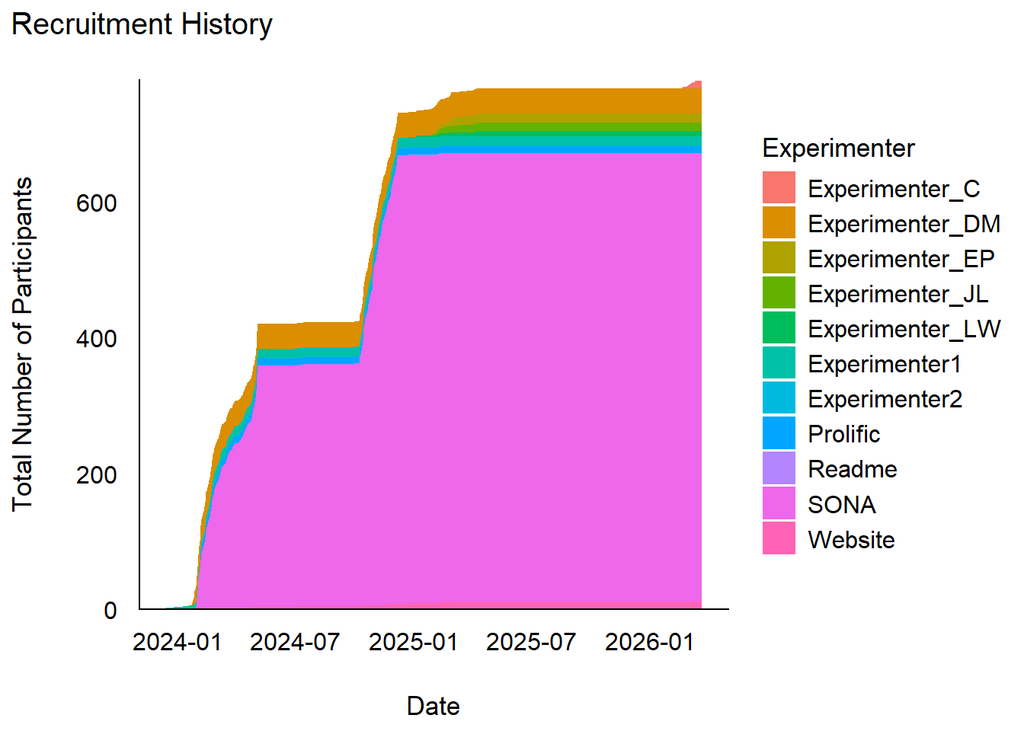

```r
# Consecutive count of participants per day (as area)
dfsub |>
  mutate(Date = as.Date(Date, format = "%d/%m/%Y")) |>
  group_by(Date, Experimenter) |>
  summarize(N = n()) |>
  ungroup() |>
  complete(Date, Experimenter, fill = list(N = 0)) |>
  group_by(Experimenter) |>
  mutate(N = cumsum(N)) |>
  ggplot(aes(x = Date, y = N)) +
  geom_area(aes(fill=Experimenter)) +
  scale_y_continuous(expand = c(0, 0)) +
  labs(
    title = "Recruitment History",
    x = "Date",
    y = "Total Number of Participants"
  ) +
  see::theme_modern()
```

### Experiment Duration

The experiment’s median duration is 26.09 min (50% HDI [20.89, 28.08]).

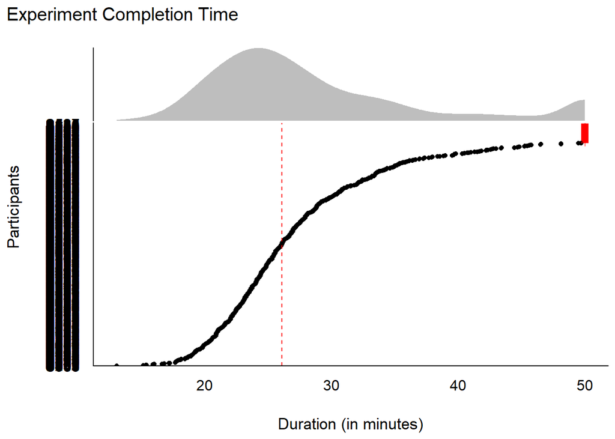

```r
dfsub |>
  mutate(Participant = fct_reorder(Participant, Experiment_Duration),
         Category = ifelse(Experiment_Duration > 50, "extra", "ok"),
         Duration = ifelse(Experiment_Duration > 50, 50, Experiment_Duration)) |>
  ggplot(aes(y = Participant, x = Duration)) +
  geom_point(aes(color = Category, shape = Category)) +
  geom_vline(xintercept = median(dfsub$Experiment_Duration), color = "red", linetype = "dashed") +
  scale_shape_manual(values = c("extra" = 3, ok = 19)) +
  scale_color_manual(values = c("extra" = "red", ok = "black")) +
  guides(color = "none", shape = "none") +
  ggside::geom_xsidedensity(fill = "grey", color=NA) +
  ggside::scale_xsidey_continuous(expand = c(0, 0)) +
  labs(
    title = "Experiment Completion Time",
    x = "Duration (in minutes)",
    y = "Participants"
  )  +
  see::theme_modern() +
  ggside::theme_ggside_void() +
  theme(ggside.panel.scale = .3,
        axis.text.y = element_blank())
```

### Questionnaire Score Computation

#### IPIP6

```r
SD_per_dim <- function(x, dims="") {
  m <- matrix(nrow=nrow(x), ncol=0)
  for(s in dims) {
    m <- cbind(m, sapply(as.data.frame(t(x[grepl(s, names(x))])), sd))
  }
  m
}
```

```r
ipip6 <- select(dfsub, starts_with("IPIP6_"), -IPIP6_Duration, -IPIP6_Order)
ipip6[grepl("_R", names(ipip6))] <- 1 - ipip6[grepl("_R", names(ipip6))]

dfsub$IPIP6_Extraversion <- rowMeans(ipip6[grepl("Extraversion", names(ipip6))])
dfsub$IPIP6_Conscientiousness <- rowMeans(ipip6[grepl("Conscientiousness", names(ipip6))])
dfsub$IPIP6_Neuroticism <- rowMeans(ipip6[grepl("Neuroticism", names(ipip6))])
dfsub$IPIP6_Openness <- rowMeans(ipip6[grepl("Openness", names(ipip6))])
dfsub$IPIP6_HonestyHumility <- rowMeans(ipip6[grepl("HonestyHumility", names(ipip6))])
dfsub$IPIP6_Agreeableness <- rowMeans(ipip6[grepl("Agreeableness", names(ipip6))])
dfsub$IPIP6_SD <- rowMeans(SD_per_dim(ipip6, c("Extraversion", "Conscientiousness", "Neuroticism",
                                               "Openness", "HonestyHumility", "Agreeableness")))
```

#### PID-5

```r
pid5 <- select(dfsub, starts_with("PID5_"), -PID5_Duration, -PID5_Order)

dfsub$PID5_Disinhibition <- rowMeans(pid5[grepl("Disinhibition", names(pid5))])
dfsub$PID5_Detachment <- rowMeans(pid5[grepl("Detachment", names(pid5))])
dfsub$PID5_NegativeAffect <- rowMeans(pid5[grepl("NegativeAffect", names(pid5))])
dfsub$PID5_Antagonism <- rowMeans(pid5[grepl("Antagonism", names(pid5))])
dfsub$PID5_Psychoticism <- rowMeans(pid5[grepl("Psychoticism", names(pid5))])
dfsub$PID5_SD <- rowMeans(SD_per_dim(pid5, c("Disinhibition", "Detachment", "NegativeAffect",
                                             "Antagonism", "Psychoticism")))
```

#### SSS

```r
sss <- select(dfsub, starts_with("SSS_"), -SSS_Duration, -SSS_Order)

dfsub$SSS_General <- rowMeans(sss / 4)

dfsub$SSS_SD <- rowMeans(SD_per_dim(sss, c("SSS")))
```

#### MIST-16

From Maertens et al. (2023): *“We recommend to calculate and report all five scores of the Verification done framework”*:

- V (Veracity Discernment): V can be calculated by scoring each of the responses on a binary 0 (incorrect) or 1 (correct) metric and taking the sum of the score.
- r (Real News Detection): The sum of all scores for the real news items results in the r score.
- f (Fake News Detection): The sum of all scores for the fake news items results in the f score.
- d (Distrust): To calculate d, all responses must be scored on a binary 0 (not fake news) or 1 (fake news) metric, independent of whether the response is correct or incorrect. The sum of this amount of fake news judgements should then be subtracted by 10 (MIST-20), 8 (MIST-16), or 4 (MIST-8), and this results in the distrust score. If the resulting score is below 0, the score should be corrected to 0.
- n (Naïvité): To calculate n, all responses must be scored on a binary 0 (not real news) or 1 (real news), independent of whether the response is correct or incorrect. The sum of this amount of real news judgements should then be subtracted by 10 (MIST-20), 8 (MIST-16), or 4 (MIST-8), and this results in the naïvité score. If the resulting score is below 0, the score should be corrected to 0.

```r
mist <- select(dfsub, starts_with("MIST_"), -MIST_Duration, -MIST_Order)

dfsub$MIST_RealDetection <- rowSums(mist[grepl("Real", names(mist))])
dfsub$MIST_FakeDetection <- rowSums(mist[grepl("Fake", names(mist))] == 0)
dfsub$MIST_Discernment <- dfsub$MIST_RealDetection + dfsub$MIST_FakeDetection
dfsub$MIST_Distrust <- rowSums(mist == 0) - 8
dfsub$MIST_Naivete <- rowSums(mist) - 8

dfsub$MIST_SD <- rowMeans(SD_per_dim(mist, c("MIST"))) # I've added this in - needs checking!
```

## Exclusion

### Illusion Game

We removed participants with an error rate > 45% (suggesting chance-level, i.e., random, responding) for any of the illusion types. Outliers detected in the first block (A) have been excluded entirely (suggesting that they did not properly do the task), but if only the second set (B) was bad, then only this set was discarded (suggesting that participants became “bored” when having to re-do the task), where illusion sensitivity can still be estimated, albeit with less precision. Additionally, participants with significantly slower RTs than the group average (RT > 4 SD above the mean, possibly indicative of a different strategy) were excluded from the analysis entirely.

```r
data_outliers <- df |>
    summarize(
        p_Error = sum(Error) / n(),
        z_RT = mean(RT),
        .by = c("Participant", "Illusion_Type", "Block")
    ) |>
    mutate(z_RT = as.numeric(standardize(z_RT)), .by = c("Illusion_Type", "Block")) |>
    arrange(desc(p_Error))

rt_params <- df |>
    summarize(
        p_Error = sum(Error) / n(),
        mean_RT = mean(RT),
        .by = c("Participant", "Illusion_Type", "Block")
    ) |>
    summarize(
        orig_mean = mean(mean_RT),
        orig_sd   = sd(mean_RT),
        .by = c("Illusion_Type", "Block")
    )

outliers <- filter(data_outliers, p_Error > 0.45 | z_RT > 4)

outliers_full_error <- unique(filter(data_outliers, Block == "A" & p_Error > 0.45)$Participant)
outliers_full_rt <- unique(filter(data_outliers, z_RT > 4)$Participant)
outliers_full <- unique(c(outliers_full_error, outliers_full_rt))

outliers_half <- unique(filter(data_outliers, Block == "B" & p_Error > 0.45)$Participant)
outliers_half <- outliers_half[!(outliers_half %in% outliers_full)]
```

#### Before Exclusion

**Error Rate**

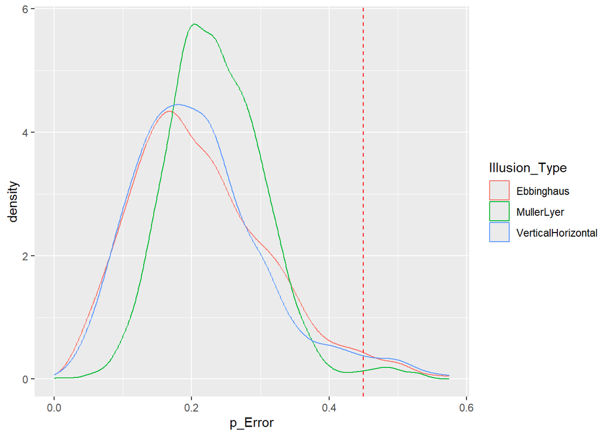

```r
p1 <- data_outliers |>
    ggplot(aes(x = p_Error)) +
    geom_density(aes(colour = Illusion_Type)) +
    geom_vline(xintercept = 0.45, linetype = "dashed", color = "red")

p1
```

**Mean RT**

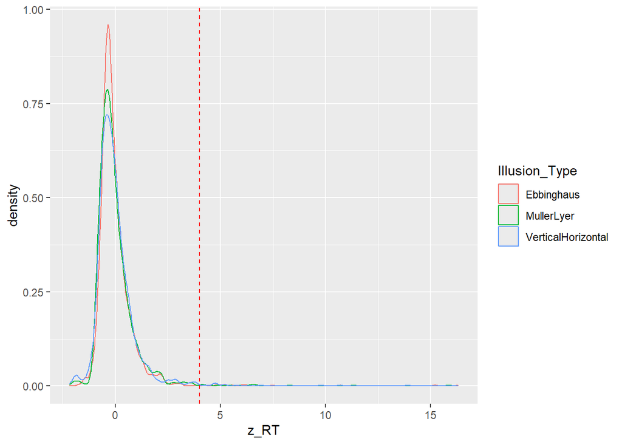

```r
p2 <- data_outliers |>
    ggplot(aes(x = z_RT)) +
    geom_density(aes(color = Illusion_Type)) +
    geom_vline(xintercept = 4, linetype = "dashed", color = "red")

p2
```

We discarded 38 participants (entirely) and 25 participant’s second blocks.

```r
df <- df |>
   filter(!Participant %in% outliers_full) |>
   filter(!((Block == "B") & (Participant %in% outliers_half)))
```

**Exclusions Table**

```r
outliers_tib <- tibble(
    "Participant" = outliers_full,
    "Reason for Exclusion" = case_when(
        Participant %in% outliers_full_error & Participant %in% outliers_full_rt ~ "High error (Block A) + Slow RT",
        Participant %in% outliers_full_error ~ "High error (Block A)",
        Participant %in% outliers_full_rt ~ "Slow RT (> 4 SD)"
    ),
    "Extent of Exclusion" = "Participant-level"
) |>
bind_rows(
    tibble(
      "Participant" = outliers_half,
      "Reason for Exclusion" = "High error (Block B only)",
      "Extent of Exclusion" = "Block-level"
      )
)

outliers_tib |>
  kable(caption = "Exclusions From Illusion Game Data") |>
  scroll_box(height = "300px") |>
  kable_styling()
```

Exclusions From Illusion Game Data

| Participant | Reason for Exclusion | Extent of Exclusion |
| --- | --- | --- |
| S388 | High error (Block A) | Participant-level |
| S403 | High error (Block A) | Participant-level |
| S402 | High error (Block A) | Participant-level |
| S626 | High error (Block A) | Participant-level |
| S144 | High error (Block A) | Participant-level |
| S087 | High error (Block A) | Participant-level |
| S423 | High error (Block A) + Slow RT | Participant-level |
| S438 | High error (Block A) | Participant-level |
| S394 | High error (Block A) | Participant-level |
| S533 | High error (Block A) | Participant-level |
| S183 | High error (Block A) | Participant-level |
| S377 | High error (Block A) | Participant-level |
| S609 | High error (Block A) | Participant-level |
| S205 | High error (Block A) | Participant-level |
| S307 | High error (Block A) | Participant-level |
| S047 | High error (Block A) | Participant-level |
| S602 | High error (Block A) | Participant-level |
| S066 | High error (Block A) | Participant-level |
| S292 | High error (Block A) | Participant-level |
| S273 | High error (Block A) | Participant-level |
| S061 | Slow RT (> 4 SD) | Participant-level |
| S375 | Slow RT (> 4 SD) | Participant-level |
| S507 | Slow RT (> 4 SD) | Participant-level |
| S711 | Slow RT (> 4 SD) | Participant-level |
| S226 | Slow RT (> 4 SD) | Participant-level |
| S536 | Slow RT (> 4 SD) | Participant-level |
| S420 | Slow RT (> 4 SD) | Participant-level |
| S390 | Slow RT (> 4 SD) | Participant-level |
| S636 | Slow RT (> 4 SD) | Participant-level |
| S414 | Slow RT (> 4 SD) | Participant-level |
| S393 | Slow RT (> 4 SD) | Participant-level |
| S425 | Slow RT (> 4 SD) | Participant-level |
| S703 | Slow RT (> 4 SD) | Participant-level |
| S652 | Slow RT (> 4 SD) | Participant-level |
| S444 | Slow RT (> 4 SD) | Participant-level |
| S770 | Slow RT (> 4 SD) | Participant-level |
| S128 | Slow RT (> 4 SD) | Participant-level |
| S744 | Slow RT (> 4 SD) | Participant-level |
| S592 | High error (Block B only) | Block-level |
| S039 | High error (Block B only) | Block-level |
| S400 | High error (Block B only) | Block-level |
| S433 | High error (Block B only) | Block-level |
| S035 | High error (Block B only) | Block-level |
| S370 | High error (Block B only) | Block-level |
| S054 | High error (Block B only) | Block-level |
| S383 | High error (Block B only) | Block-level |
| S608 | High error (Block B only) | Block-level |
| S627 | High error (Block B only) | Block-level |
| S691 | High error (Block B only) | Block-level |
| S607 | High error (Block B only) | Block-level |
| S297 | High error (Block B only) | Block-level |
| S613 | High error (Block B only) | Block-level |
| S525 | High error (Block B only) | Block-level |
| S625 | High error (Block B only) | Block-level |
| S196 | High error (Block B only) | Block-level |
| S492 | High error (Block B only) | Block-level |
| S374 | High error (Block B only) | Block-level |
| S360 | High error (Block B only) | Block-level |
| S700 | High error (Block B only) | Block-level |
| S098 | High error (Block B only) | Block-level |
| S619 | High error (Block B only) | Block-level |
| S309 | High error (Block B only) | Block-level |
| S053 | High error (Block B only) | Block-level |

**Exclusions Bar Graph**

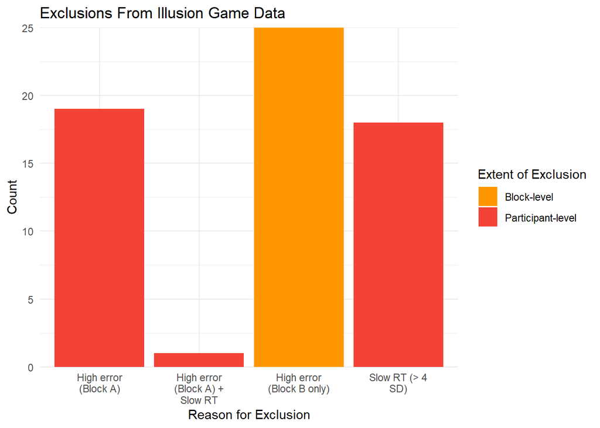

```r
outliers_bar <- outliers_tib |>
  count(`Reason for Exclusion`, `Extent of Exclusion`) |>
  ggplot(aes(x = `Reason for Exclusion`, y = n, fill = `Extent of Exclusion`)) +
  geom_bar(stat = "identity") +
  scale_fill_manual(values = c("Participant-level" = "#F44336", "Block-level" = "#FF9800")) +
  scale_x_discrete(labels = scales::label_wrap(15)) +
  scale_y_continuous(expand = c(0, 0), limits = c(0, NA)) +
  labs(
    title = "Exclusions From Illusion Game Data",
    x = "Reason for Exclusion",
    y = "Count",
    fill = "Extent of Exclusion"
  ) +
  theme_minimal()

outliers_bar
```

We removed individual extreme trials (RT < 0.2 s or > 5 s; Thériault et al., 2024) to mitigate the risk of confounding effects driven by extreme speed or accuracy strategies.

```r
n_before <- nrow(df)
df <- filter(df, RT > 0.2 & RT < 5)
n_removed <- n_before - nrow(df)
```

This removed 1383 trials (0.39% of total).

```r
dfsub <- filter(dfsub, !Participant %in% outliers_full)
df <- filter(df, Participant %in% dfsub$Participant)
```

```r
# Using original mean and SD (from before exclusion) so z_RT remains on same scale (rather than being refitted to filtered df) - I might have done this incorrectly, though!

data_kept <- df |>
    summarize(
      p_Error = sum(Error) / n(),
      mean_RT  = mean(RT),
      .by = c("Participant", "Illusion_Type", "Block")
  ) |>
  left_join(rt_params, by = c("Illusion_Type", "Block")) |>
  mutate(z_RT = (mean_RT - orig_mean) / orig_sd) |>
  select(-mean_RT, -orig_mean, -orig_sd) |>
  arrange(desc(p_Error))
```

```r
# I'm leaving this in in case it's important

#outliers <- c("S043", "S079")
#outliers_half <- c("S032", "S049")
```

#### After Exclusion

**Error Rate**

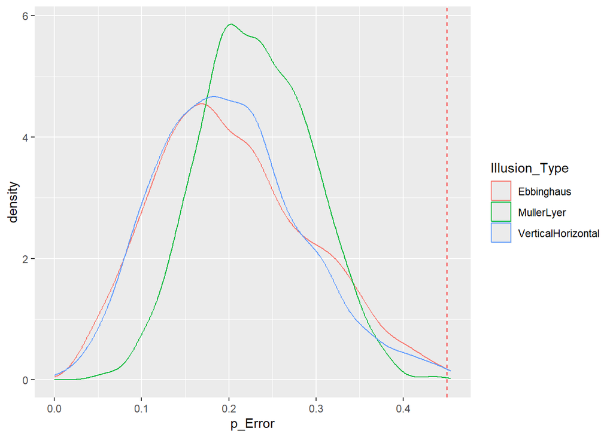

```r
p1 <- data_kept |>
    ggplot(aes(x = p_Error)) +
    geom_density(aes(colour = Illusion_Type)) +
    geom_vline(xintercept = 0.45, linetype = "dashed", color = "red")

p1
```

**Mean RT (Original Standardisation Parameters)**

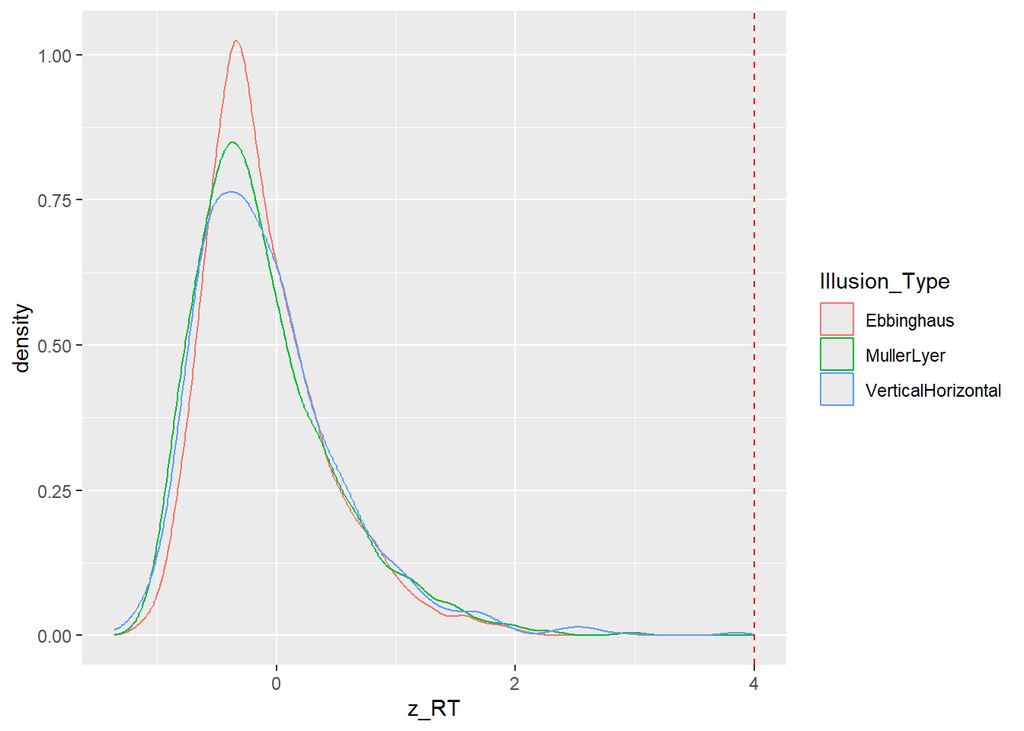

```r
p2 <- data_kept |>
    ggplot(aes(x = z_RT)) +
    geom_density(aes(color = Illusion_Type)) +
    geom_vline(xintercept = 4, linetype = "dashed", color = "red")

p2
```

#### Reaction Time (per Block)

```r
d_all <- estimate_density(df$RT)

plot_distribution <- function(dat) {

  data_error <- data_outliers |>
    filter(Participant %in% unique(dat$Participant)) |>
    group_by(Participant, Block) |>
    summarize(y = mean(p_Error), .groups = "drop") |>
    mutate(
      x = ifelse(Block == "A", 2.1, 2.3),
      color = case_when(
        Participant %in% outliers_full ~ "red",
        Participant %in% outliers_half ~ "orange",
        TRUE ~ "blue"
      )
    )

dat |>
  group_by(Participant, Block) |>
  group_modify(~estimate_density(.x$RT)) |>
  ungroup() |>
  group_by(Participant) |>
  normalize(select = "y") |>
  ungroup() |>
  mutate(
    Participant = fct_relevel(Participant, sort(unique(dat$Participant))),
    color = case_when(
      Participant %in% outliers_full ~ "red",
      Participant %in% outliers_half ~ "orange",
      TRUE ~ "blue"
    )
  ) |>
    ggplot(aes(x = x, y = y)) +
    geom_bar(data = data_error, aes(fill = color), stat = "identity", width = 0.19) +
    geom_segment(aes(x = 2, xend = 2.4, y = 0.5, yend = 0.5), color = "black", linetype = "dashed", linewidth = 0.5) +
    geom_area(data = normalize(d_all, select = "y"), alpha = 0.2) +
    geom_line(aes(color = color, group = interaction(Participant, Block), linetype = Block), linewidth = 0.8) +
    scale_color_manual(values = c("red" = "#F44336", "orange" = "#FF9800", "blue" = "blue"), guide = "none") +
    scale_fill_manual(values = c("red" = "#F44336", "orange" = "#FF9800", "blue" = "blue"), guide = "none") +
    scale_x_continuous(expand = c(0, 0), breaks = c(0, 0.5, 1, 1.5, 2), labels = c("0", "0.5", "1", "1.5", "2")) +
    scale_y_continuous(expand = c(0, 0)) +
    coord_cartesian(xlim = c(0, 2.4)) +
    theme_modern() +
    theme(
      axis.text.y = element_blank(),
      axis.line.y = element_blank(),
      strip.text.x = element_text(size = rel(1.5)),
      legend.position = "none"
    ) +
    facet_wrap(~Participant, nrow = 10) +
    labs(y = "", x = "Reaction Time (s)")
}
```

**1-100**

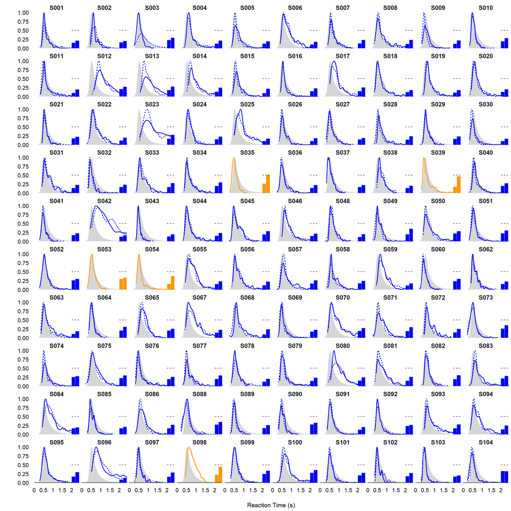

```r
plot_distribution(df[df$Participant %in% dfsub$Participant[1:100], ])
```

**101-200**

```r
#plot_distribution(df[df$Participant %in% dfsub$Participant[101:200], ])
```

**201-300**

```r
#plot_distribution(df[df$Participant %in% dfsub$Participant[201-300], ])
```

**301-400**

```r
#plot_distribution(df[df$Participant %in% dfsub$Participant[301-400], ])
```

**401-500**

```r
#plot_distribution(df[df$Participant %in% dfsub$Participant[401-500], ])
```

**501-600**

```r
#plot_distribution(df[df$Participant %in% dfsub$Participant[501-600], ])
```

**601-700**

```r
#plot_distribution(df[df$Participant %in% dfsub$Participant[601-700], ])
```

**701-800**

```r
#plot_distribution(df[df$Participant %in% dfsub$Participant[701-800], ])
```

#### Reaction Time (per Block) - potentially redundant code here? Unless we use these cutoff criteria instead of those used above (although, the criteria above mirrors the IGPCS manuscript)

```r
## I've kept this in for the time being as it uses different cutoff criteria

#check_trials <- function(df) {
  #data <- df |>
    #mutate(Outlier = ifelse(RT >= 10, TRUE, FALSE)) |>
    #group_by(Participant) |>
    #mutate(Outlier = ifelse(RT < 0.150 | standardize(RT, robust = TRUE) > 4, TRUE, Outlier)) |>
    #ungroup()

  #p1 <- data |>
    #filter(RT < 10) |>
    #estimate_density(select = "RT", at = "Participant") |>
    #group_by(Participant) |>
    #normalize(select = "y") |>
    #ungroup() |>
    #merge(data |>
      #group_by(Participant) |>
      #mutate(Threshold = median(RT) + 4 * mad(RT)) |>
      #filter(Error == 0) |>
      #summarize(Threshold = mean(Threshold))) |>
    #mutate(Outlier = ifelse(x >= Threshold, TRUE, FALSE)) |>
    #ggplot(aes(x = x, y = y)) +
    #geom_area(data = normalize(estimate_density(filter(data, RT < 10), select = "RT"), select = "y"), alpha = 0.2) +
    #geom_line(aes(color = Participant, linetype = Outlier), alpha = 0.2) +
    #geom_vline(xintercept = c(125), linetype = "dashed", color = "red") +
    #scale_color_material_d("rainbow", guide = "none") +
    #scale_x_continuous(expand = c(0, 0)) +
    #scale_y_continuous(expand = c(0, 0)) +
    #guides(linetype = "none") +
    #coord_cartesian(xlim = c(0, 5)) +
    #theme_modern() +
    #theme(axis.text.y = element_blank()) +
    #labs(y = "", x = "Reaction Time (s)")


  #p2 <- data |>
    #group_by(Participant) |>
    #summarize(Outlier = sum(Outlier) / n()) |>
    #mutate(Participant = fct_reorder(Participant, Outlier)) |>
    #ggplot(aes(x = Participant, y = Outlier)) +
    #geom_bar(stat = "identity", aes(fill = Participant)) +
    #scale_fill_material_d("rainbow", guide = "none") +
    #scale_x_discrete(expand = c(0, 0)) +
    #scale_y_continuous(expand = c(0, 0), labels = scales::percent) +
    #see::theme_modern() +
    #theme(axis.text.x = element_blank()) +
    #labs(y = "Percentage of outlier trials")

  #text <- paste0(
    #"We removed ",
    #sum(data$Outlier),
    #" (",
    #insight::format_value(sum(data$Outlier) / nrow(data), as_percent = TRUE),
    #") outlier trials (200 ms < RT < 4 MAD above median)."
  #)

  #data <- filter(data, Outlier == FALSE)
  #data$Outlier <- NULL

  #list(p = p1 / p2, data = data, text = text)
#}
```

```r
#out <- check_trials(df)
#out$text
#out$p
#df <- out$data
```

### Questionnaires

```r
outliers_qs <- dfsub |>
  select(IPIP6_SD, IPIP6_Duration, PID5_SD, PID5_Duration, SSS_SD, SSS_Duration, MIST_SD, MIST_Duration) |> #I've added in SD and Duration columns for MIST
  standardize(robust=TRUE) |>
  mutate(SD = rowSums(across(ends_with("SD"))), Duration = rowSums(across(ends_with("Duration"))))

table <- dfsub |>
  select(Participant, IPIP6_SD, IPIP6_Duration, PID5_SD, PID5_Duration, SSS_SD, SSS_Duration, MIST_SD, MIST_Duration) |>
  mutate_at(vars(ends_with("Duration")), \(x) ifelse(x > 10, 10, x)) |>
  mutate(Participant = fct_reorder(Participant, desc(outliers_qs$SD))) |>
  arrange(Participant)

data.frame(Participant = c("Average"), t(sapply(table[2:ncol(table)], mean, na.rm = TRUE))) |>
  rbind(table) |>
  gt::gt() |>
  gt::fmt_number() |>
  gt::data_color(columns = "Participant", fn=\(x) ifelse(x %in% outliers_half, "orange", "white")) |>
  gt::data_color(columns = ends_with("Duration"),
                 direction="column", palette = "RdBu") |>
  gt::data_color(columns = ends_with("SD"),
                 direction="column", palette = "RdBu", reverse=TRUE) |>
  gt::data_color(direction="row", rows=1, palette = "grey") |>
  gt::opt_interactive(use_compact_mode = TRUE)
```

| Participant | IPIP6_SD | IPIP6_Duration | PID5_SD | PID5_Duration | SSS_SD | SSS_Duration | MIST_SD | MIST_Duration |
| --- | --- | --- | --- | --- | --- | --- | --- | --- |
| Average | 0.166544918938989 | 1.80296153796048 | 0.709364529072898 | 2.56501120844564 | 1.06647031448175 | 1.85263034591195 | 0.494949976312138 | 2.15157190026954 |
| S172 | 0.339928809410056 | 4.06501000000002 | 0.997334923329992 | 2.92148333333333 | 1.48002573980191 | 3.58475 | 0.51234753829798 | 3.66223333333333 |
| S288 | 0.195729809411603 | 1.8933566666667 | 1.13338295228033 | 7.60461666666667 | 1.82964997953681 | 1.62101666666667 | 0.51234753829798 | 4.18341666666667 |
| S112 | 0.321475836779979 | 0.914626666666071 | 1.11849788421929 | 10 | 1.71686314178476 | 0.932833333333333 | 0.5 | 0.979183333333333 |
| S545 | 0.294854059443748 | 0.7921 | 0.981605288878267 | 1.53498333333333 | 1.46059348668044 | 2.4246 | 0.51234753829798 | 0.66635 |
| S376 | 0.29554300685282 | 1.73304500000079 | 0.817526203209097 | 1.87648333333333 | 1.45896244933563 | 1.30285 | 0.516397779494322 | 1.26143333333333 |
| S452 | 0.253885810888879 | 2.014675 | 0.969039086586124 | 3.0286 | 1.41925533794512 | 2.31306666666667 | 0.516397779494322 | 3.14248333333333 |
| S558 | 0.281221336730102 | 1.17396666666667 | 0.963451849359727 | 3.32658333333333 | 1.37494588638106 | 1.7197 | 0.51234753829798 | 1.98101666666667 |
| S549 | 0.354722636930667 | 2.08442000000079 | 0.90391315113054 | 1.64716666666667 | 1.53684897172909 | 1.46406666666667 | 0.5 | 3.68548333333333 |
| S616 | 0.220165493799025 | 1.29923833333333 | 1.22821331736913 | 1.82501666666667 | 1.24976188208185 | 1.30636666666667 | 0.51234753829798 | 1.66016666666667 |

[output cut: 733 more lines]

```r
# create code to exclude questionnaire responses

# include the MIST here too? I've included it (SD and Duration) - will need double-checking I've done everything correctly
# presumably PPs will be excluded for answering within a certain SD above the mean?
# PPs also excluded for taking too little/much time?
# factor in questionnaire item order?
```

## Final Sample

**Summary**

The final sample includes 742 participants (Mean age = 22.0, SD = 8.4, range: [16, 73]; Gender: 75.5% women, 21.4% men, 2.96% non-binary, 0.13% missing; Education: Bachelor, 19.95%; Doctorate, 1.35%; High School, 69.95%; Master, 3.10%; missing, 0.13%; Other, 5.53%), for a total trial number of 348777.

**Age and Gender**

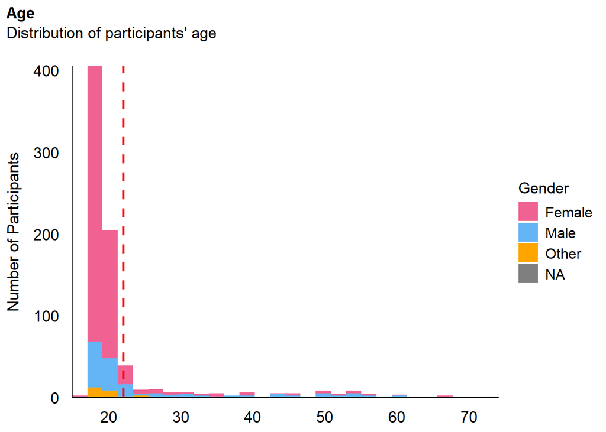

```r
p_age <- estimate_density(dfsub$Age) |>
  normalize(select = y) |>
  mutate(y = y * 86) |>  # To match the binwidth
  ggplot(aes(x = x)) +
  geom_histogram(data=dfsub, aes(x = Age, fill=Gender), bins=28) +
  # geom_line(aes(y = y), color = "orange", linewidth=2) +
  geom_vline(xintercept = mean(dfsub$Age), color = "red", linewidth=1, linetype = "dashed") +
  # geom_label(data = data.frame(x = mean(df$Age) * 1.15, y = 0.95 * 75), aes(y = y), color = "red", label = paste0("Mean = ", format_value(mean(df$Age)))) +
  scale_fill_manual(values = c("Male"= "#64B5F6", "Female"= "#F06292", "Other"="orange")) +
  scale_x_continuous(expand = c(0, 0)) +
  scale_y_continuous(expand = c(0, 0)) +
  labs(title = "Age", y = "Number of Participants", color = NULL, subtitle = "Distribution of participants' age") +
  theme_modern(axis.title.space = 10) +
  theme(
    plot.title = element_text(size = rel(1.2), face = "bold", hjust = 0),
    plot.subtitle = element_text(size = rel(1.2), vjust = 7),
    axis.text.y = element_text(size = rel(1.1)),
    axis.text.x = element_text(size = rel(1.1)),
    axis.title.x = element_blank()
  )
p_age
```

**Education**

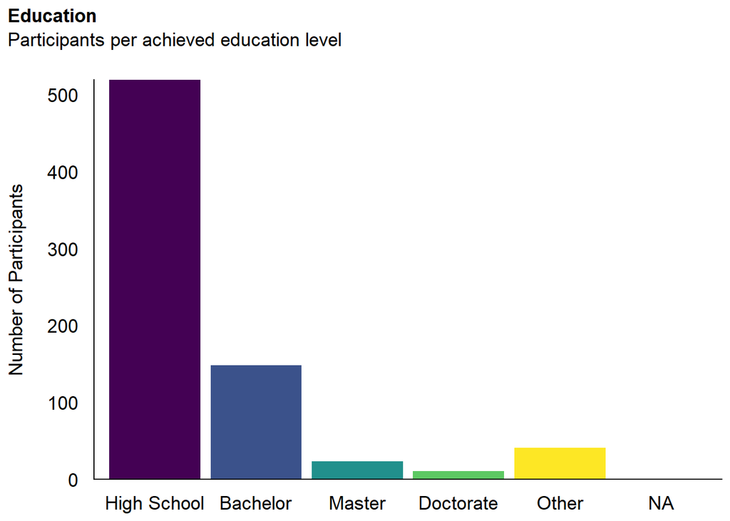

```r
p_edu <- dfsub |>
  mutate(Education = fct_relevel(Education, "High School", "Bachelor", "Master", "Doctorate", "Other")) |>
  ggplot(aes(x = Education)) +
  geom_bar(aes(fill = Education)) +
  scale_y_continuous(expand = c(0, 0), breaks= scales::pretty_breaks()) +
  scale_fill_viridis_d(guide = "none") +
  labs(title = "Education", y = "Number of Participants", subtitle = "Participants per achieved education level") +
  theme_modern(axis.title.space = 15) +
  theme(
    plot.title = element_text(size = rel(1.2), face = "bold", hjust = 0),
    plot.subtitle = element_text(size = rel(1.2), vjust = 7),
    axis.text.y = element_text(size = rel(1.1)),
    axis.text.x = element_text(size = rel(1.1)),
    axis.title.x = element_blank()
  )
p_edu
```

**Ethnicity**

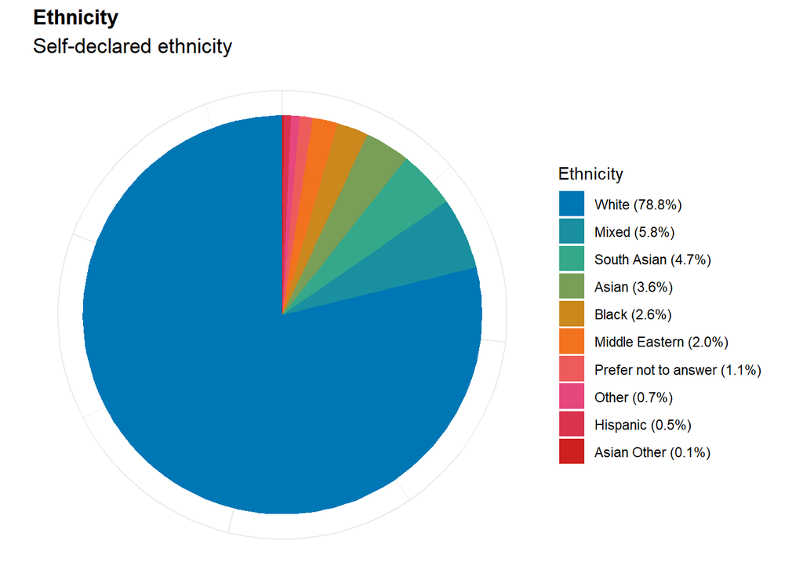

```r
p_eth <- dfsub |>
  mutate(Ethnicity = ifelse(is.na(Ethnicity), "Prefer not to answer", Ethnicity)) |>
  mutate(Freq = format_percent(n() / nrow(dfsub), digits=1), .by=Ethnicity) |>
  mutate(Ethnicity = fct_infreq(paste0(Ethnicity, " (", Freq, ")"))) |>
  ggplot(aes(x = "", fill = Ethnicity)) +
  geom_bar() +
  coord_polar("y") +
  see::scale_fill_social_d() +
  labs(title = "Ethnicity", subtitle = "Self-declared ethnicity") +
  theme_minimal() +
  theme(
    axis.text.x = element_blank(),
    axis.title.x = element_blank(),
    axis.text.y = element_blank(),
    axis.title.y = element_blank(),
    plot.title = element_text(size = rel(1.2), face = "bold", hjust = 0),
    plot.subtitle = element_text(size = rel(1.2))
  )

p_eth
```

## Save

```r
write.csv(dfsub, "C:/Users/olive/Documents/GitHub/IllusionGameSuggestibility/data/data_participants.csv", row.names = FALSE)
write.csv(df, "C:/Users/olive/Documents/GitHub/IllusionGameSuggestibility/data/data_IllusionGame.csv", row.names = FALSE)
```